# Protein contrasts

Every protein tested in each of the nine contrasts from `01_Design_Contrasts`. The fit is limma on limpa’s values, with limpa’s standard errors as precision weights, person as a block and blood as a covariate. Each effect is a log2 fold change (logFC: +1 means twice as much) with its 95% confidence interval.

## Packages

```r
library(here)
library(limma)
library(dplyr)
library(tidyr)
library(purrr)
library(tibble)
library(ggplot2)
library(grid)
library(ComplexHeatmap)
source(here("00_Setup", "Shared_functions", "analysis_reporting_helpers.R"))
source(here("00_Setup", "Shared_functions", "proteome_inputs.R"))
c(grouping = params$grouping, input = params$input)
```

```
     grouping         input
"Muscle_size"            ""
```

`design.rds` holds this grouping’s design, contrasts and people. `proteins.rds` holds limpa’s values and standard errors; `DAList_corrected.rds` the same values with blood slopes removed, used here only for the PCA and the set trajectories.

```r
input <- params$input[nzchar(params$input)]
step <- \(name) paste(c("03_Group_comparisons", params$grouping, name, input), collapse = "/")
stage <- step("02_Protein_Contrasts")
inputs <- c(
  design = file.path(step("01_Design_Contrasts"), "c_data/design.rds"),
  proteins = "01_Processing/03_Quantification/c_data/proteins.rds",
  corrected = "01_Processing/03_Quantification/c_data/DAList_corrected.rds",
  phenotype = "00_Setup/Input/phenotype.csv"
)
paths <- map_chr(inputs, here)
stopifnot(file.exists(paths))
d <- readRDS(paths[["design"]])
arms <- d$arms
dal <- d$dal
contrast_names <- colnames(dal$design$contrast_matrix)
stopifnot(identical(rownames(dal$design$design_matrix), colnames(dal$data)))
proteins <- subset_for_design(readRDS(paths[["proteins"]]), d)$proteins
design <- dal$design$design_matrix
contrast_matrix <- dal$design$contrast_matrix
meta <- dal$metadata
stopifnot(
  identical(colnames(proteins$E), rownames(design)), identical(meta$sample_id, rownames(design))
)
dim(proteins$E)
```

```
[1] 1900   45
```

## The fit

`fit_limpa_contrasts()` (shared helper) runs limpa’s `dpcDE()`: limma’s linear model with each value weighted by the inverse of its limpa standard error, so a value the detection curve had to estimate counts less than a measured one, and with person as a block. It then applies the nine contrasts and empirical Bayes moderation (`eBayes(robust = TRUE)`). Moderation borrows variance information across proteins, which steadies each protein’s own variance estimate at n = 8 per group; the robust version stops a few hypervariable proteins from distorting that borrowing (Phipson et al. 2016).

```r
eb <- fit_limpa_contrasts(proteins, design, contrast_matrix, meta$subject)
summary(eb$df.total)
```

```
   Min. 1st Qu.  Median    Mean 3rd Qu.    Max.
  41.81   43.49   43.49   43.41   43.49   43.49
```

The same nine contrasts without the blood term show how much the blood covariate moves each estimate. They are saved for comparison and decide nothing.

```r
blood_free <- design[, colnames(design) != "blood"]
raw_eb <- fit_limpa_contrasts(
  proteins, blood_free, contrast_matrix[colnames(blood_free), ], meta$subject
)
unadjusted <- tibble(
  uniprot_id = rep(rownames(proteins$E), length(contrast_names)),
  contrast = rep(contrast_names, each = nrow(proteins$E)),
  logFC = c(raw_eb$coefficients[, contrast_names]), p = c(raw_eb$p.value[, contrast_names])
) |>
  pivot_wider(names_from = contrast, values_from = c(logFC, p), names_glue = "{contrast}_{.value}")
```

## Results per protein and contrast

`topTable()` gives each protein’s logFC, its 95% confidence interval and the moderated t and p. Three corrections sit beside the nominal p, each within one contrast:

- `fdr`, Benjamini-Hochberg: the expected share of false calls among proteins called at that level;
- `qvalue`, Storey’s q (`storey_q()`): BH scaled by the estimated share of proteins with no effect;
- `pi_score`, Π = p^|logFC| (Xiao et al. 2014): small when p is small and the fold change large. Π < 0.05 currently only selects the protein sets for the fry check below.

limpa gives every protein a value in every run, so every contrast tests every protein.

```r
annotation <- as_tibble(dal$annotation)[, c("uniprot_id", "gene", "protein", "description")]
stopifnot(identical(rownames(eb$coefficients), annotation$uniprot_id))
results <- map(set_names(contrast_names), \(contrast) {
  topTable(eb, coef = contrast, number = Inf, sort.by = "none", confint = TRUE) |>
    as_tibble() |>
    select(logFC, logFC_lower = CI.L, logFC_upper = CI.R, AveExpr, t, P.Value, adj.P.Val) |>
    bind_cols(annotation, x = _)
}) |>
  list_rbind(names_to = "contrast") |>
  rename(p = P.Value, fdr = adj.P.Val) |>
  mutate(qvalue = storey_q(p), .by = contrast) |>
  mutate(
    pi_score = p^abs(logFC),
    sig_pi = case_when(
      pi_score < 0.05 & logFC > 0 ~ 1L,
      pi_score < 0.05 & logFC < 0 ~ -1L,
      TRUE ~ 0L
    )
  )
n_obs <- set_names(rowSums(proteins$other$n.observations > 0), rownames(proteins$E))
results |>
  filter(contrast == "Training_Interaction") |>
  slice_min(p, n = 5) |>
  select(gene, logFC, logFC_lower, logFC_upper, p, fdr)
```

```
# A tibble: 5 × 6
  gene     logFC logFC_lower logFC_upper       p   fdr
  <chr>    <dbl>       <dbl>       <dbl>   <dbl> <dbl>
1 PDPR     1.10        0.337       1.86  0.00570 0.999
2 LYPLA2  -0.687      -1.18       -0.191 0.00776 0.999
3 MRPL22  -0.652      -1.15       -0.155 0.0113  0.999
4 LNPEP   -1.09       -1.93       -0.251 0.0122  0.999
5 PIP4K2B  0.670       0.143       1.20  0.0139  0.999
```

```r
contrast_summary <- results |>
  summarise(
    n_tested = n(), n_nominal = sum(p < 0.05), n_fdr_05 = sum(fdr < 0.05),
    n_fdr_10 = sum(fdr < 0.10), min_fdr = min(fdr),
    .by = contrast
  ) |>
  left_join(d$roles, by = "contrast")
contrast_summary
```

```
# A tibble: 9 × 7
  contrast             n_tested n_nominal n_fdr_05 n_fdr_10 min_fdr role
  <chr>                   <int>     <int>    <int>    <int>   <dbl> <chr>
1 Training_Hi              1900       105        0        0  0.785  descriptive
2 Training_Lo              1900       102        0        0  0.176  descriptive
3 Acute_Hi                 1900       189        0        1  0.0508 descriptive
4 Acute_Lo                 1900        73        0        0  0.796  descriptive
5 Baseline_HivLo           1900        60        0        0  1.000  floor
6 Trained_HivLo            1900        55        0        0  1.000  descriptive
7 Acute_HivLo              1900       138        0        0  0.410  descriptive
8 Training_Interaction     1900        41        0        0  0.999  primary
9 Acute_Interaction        1900        79        0        0  0.966  secondary
```

## Is each test calibrated?

Under no effect at all, p values are flat, median |t| is about 0.674 and 20% of p fall below 0.2. limma’s `propTrueNull()` saturates at 1, so it cannot tell a flat null from a conservative test; median |t| and the share of p below 0.2 can.

```r
null_calibration <- results |>
  summarise(
    prop_true_null = round(propTrueNull(p), 3),
    median_abs_t = round(median(abs(t)), 3),
    p_below_0.2 = round(mean(p < 0.2), 3), .by = contrast
  )
null_calibration
```

```
# A tibble: 9 × 4
  contrast             prop_true_null median_abs_t p_below_0.2
  <chr>                         <dbl>        <dbl>       <dbl>
1 Training_Hi                   0.931        0.757       0.231
2 Training_Lo                   0.999        0.665       0.186
3 Acute_Hi                      0.836        0.883       0.309
4 Acute_Lo                      1            0.615       0.164
5 Baseline_HivLo                1            0.607       0.161
6 Trained_HivLo                 1            0.574       0.142
7 Acute_HivLo                   0.947        0.74        0.25
8 Training_Interaction          1            0.581       0.136
9 Acute_Interaction             0.997        0.693       0.203
```

The smallest effect the primary contrast could detect with 80% power at a two-sided 0.05, from each protein’s moderated standard error:

```r
se <- eb$stdev.unscaled[, "Training_Interaction"] * sqrt(eb$s2.post)
detectable <- se * (qt(0.975, eb$df.total) + qt(0.80, eb$df.total))
quantile(detectable, c(0.5, 0.9), na.rm = TRUE)
```

```
      50%       90%
0.9540582 1.4893052
```

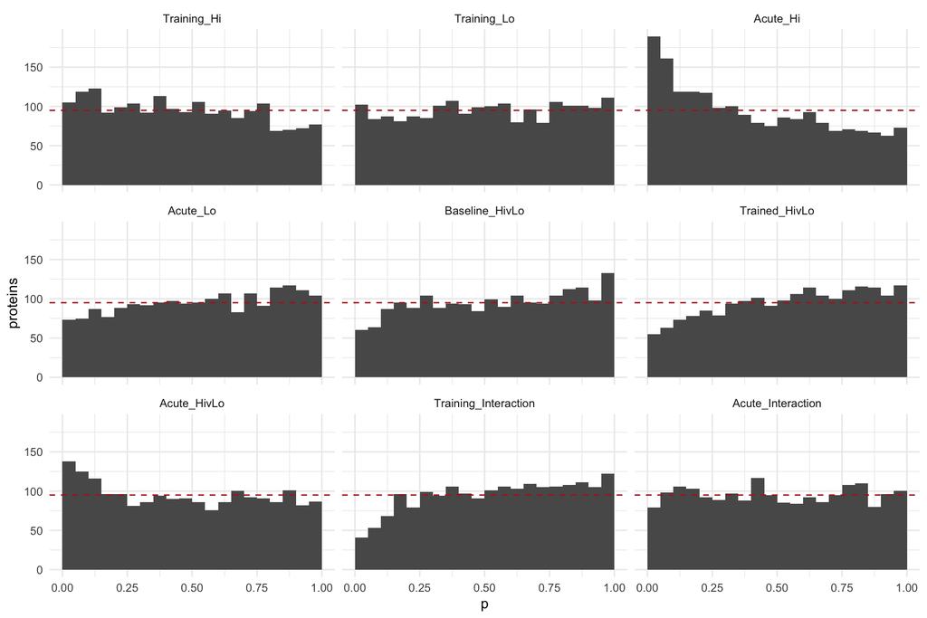

Figure 1: p values per contrast. Dashed: a flat null (tested / 20).

```r
results |>
  mutate(contrast = factor(contrast, levels = contrast_names)) |>
  ggplot(aes(p)) +
  geom_histogram(binwidth = 0.05, boundary = 0, fill = "grey35") +
  geom_hline(
    aes(yintercept = n_tested / 20),
    mutate(contrast_summary, contrast = factor(contrast, levels = contrast_names)),
    linetype = 2, colour = "firebrick"
  ) +
  facet_wrap(~contrast) +
  labs(x = "p", y = "proteins") +
  theme_minimal(base_size = 10)
```

A spike at zero on a flat background is signal; a slope up towards 1 is a conservative test.

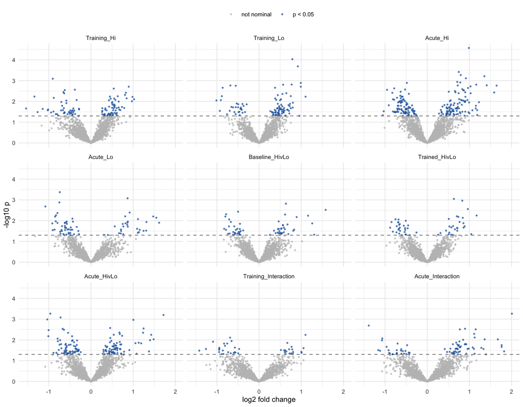

Figure 2: Volcano per contrast. Dashed: p = 0.05. Labels: BH < 0.05.

```r
results |>
  mutate(
    contrast = factor(contrast, levels = contrast_names),
    call = case_when(fdr < 0.05 ~ "BH < 0.05", p < 0.05 ~ "p < 0.05", TRUE ~ "not nominal")
  ) |>
  ggplot(aes(logFC, -log10(p), colour = call)) +
  geom_point(size = 0.6, alpha = 0.7) +
  geom_hline(yintercept = -log10(0.05), linetype = 2, colour = "grey50") +
  ggrepel::geom_text_repel(
    aes(label = gene),
    data = \(x) filter(x, fdr < 0.05), size = 2.2, show.legend = FALSE
  ) +
  facet_wrap(~contrast) +
  scale_colour_manual(
    values = c(`BH < 0.05` = "#B2182B", `p < 0.05` = "#2166AC", `not nominal` = "grey75"),
    name = NULL
  ) +
  labs(x = "log2 fold change", y = "-log10 p") +
  theme_minimal(base_size = 9) +
  theme(legend.position = "top")
```

## Do one group’s responders move in the other group?

Proteins one group changes at p < 0.05 are partly chance, and their fold change in that group is inflated by the selection. Testing the same proteins in the other group’s contrast, which uses different people, asks whether the change carries over. fry (limma) tests a whole set at once, treating people as the unit. Sets come from three criteria (Π, BH, nominal) and two directions, and need at least 5 proteins.

Only the other-group pairings share no cell mean. A training set tested on its own group’s acute contrast shares T2, so a protein high at T2 by chance reads as up then down; those rows are reported but carry that caution. fry reads limpa’s complete matrix with the same design and block; the within-person correlation comes from `duplicateCorrelation()`.

```r
abundance <- proteins$E
within_subject <- duplicateCorrelation(abundance, design, block = meta$subject)
fry_correlation <- within_subject$consensus.correlation
member_rows <- function(cn, criterion, direction) {
  r <- filter(results, contrast == cn)
  sign_ok <- if (direction == "up") r$logFC > 0 else r$logFC < 0
  hit <- switch(criterion,
    pi = r$sig_pi == if (direction == "up") 1L else -1L,
    bh = r$fdr < 0.05 & sign_ok,
    nominal = r$p < 0.05 & sign_ok
  )
  which(rownames(abundance) %in% r$uniprot_id[hit])
}
training <- paste0("Training_", arms)
acute <- paste0("Acute_", arms)
pairings <- tribble(
  ~set_from, ~ranked_on,
  training[1], training[2],
  training[2], training[1],
  acute[1], acute[2],
  acute[2], acute[1],
  training[1], acute[1],
  training[1], acute[2],
  training[2], acute[2],
  training[2], acute[1]
)
selections <- expand_grid(criterion = c("pi", "bh", "nominal"), direction = c("up", "down"))
```

For each pairing, `fry()` gets every selected set of 5 or more proteins. Beside each test sits the set’s mean logFC in the group that chose it (inflated by the choice) and in the other contrast, and the share of members whose sign carries over. fry drops its FDR column when handed a single set, so a pairing needs at least two sets.

```r
fry_concordance <- pmap(pairings, \(set_from, ranked_on) {
  sets <- pmap(selections, \(criterion, direction) member_rows(set_from, criterion, direction)) |>
    set_names(paste(selections$criterion, selections$direction, sep = "_"))
  sets <- keep(sets, \(rows) length(rows) >= 5)
  if (length(sets) < 2) {
    return(NULL)
  }
  log_fc <- \(cn, rows) filter(results, contrast == cn)$logFC[rows]
  carried <- imap(sets, \(rows, set) {
    own <- log_fc(set_from, rows)
    other <- log_fc(ranked_on, rows)
    tibble(
      set,
      mean_logfc_own = mean(own), mean_logfc_other = mean(other),
      same_sign_share = mean(sign(own) == sign(other))
    )
  }) |>
    list_rbind()
  fry(abundance,
    index = sets, design = design, contrast = contrast_matrix[, ranked_on],
    block = meta$subject, correlation = fry_correlation
  ) |>
    as_tibble(rownames = "set") |>
    transmute(
      set_from, ranked_on, set,
      n_proteins = NGenes, direction = Direction, p = PValue, fdr = FDR,
      p_mixed = PValue.Mixed, fdr_mixed = FDR.Mixed
    ) |>
    left_join(carried, by = "set")
}) |>
  list_rbind()
fry_concordance |>
  filter(set == "nominal_up" | set == "nominal_down") |>
  select(set_from, ranked_on, set, n_proteins, direction, p, same_sign_share)
```

```
# A tibble: 16 × 7
   set_from    ranked_on   set      n_proteins direction       p same_sign_share
   <chr>       <chr>       <chr>         <int> <chr>       <dbl>           <dbl>
 1 Training_Hi Training_Lo nominal…         59 Up        3.41e-2          0.898
 2 Training_Hi Training_Lo nominal…         46 Down      1.77e-1          0.739
 3 Training_Lo Training_Hi nominal…         73 Up        3.88e-3          0.822
 4 Training_Lo Training_Hi nominal…         29 Down      1.31e-2          0.759
 5 Acute_Hi    Acute_Lo    nominal…         88 Down      3.04e-1          0.773
 6 Acute_Hi    Acute_Lo    nominal…        101 Up        4.37e-1          0.574
 7 Acute_Lo    Acute_Hi    nominal…         44 Down      3.39e-4          0.864
 8 Acute_Lo    Acute_Hi    nominal…         29 Up        8.79e-3          0.759
 9 Training_Hi Acute_Hi    nominal…         46 Up        3.89e-3          0.109
10 Training_Hi Acute_Hi    nominal…         59 Down      4.40e-3          0.0847
11 Training_Hi Acute_Lo    nominal…         59 Down      3.21e-1          0.271
12 Training_Hi Acute_Lo    nominal…         46 Up        9.15e-1          0.457
13 Training_Lo Acute_Lo    nominal…         73 Down      2.65e-6          0.0274
14 Training_Lo Acute_Lo    nominal…         29 Up        5.46e-4          0.103
15 Training_Lo Acute_Hi    nominal…         73 Down      5.43e-2          0.301
16 Training_Lo Acute_Hi    nominal…         29 Up        5.68e-1          0.448
```

## Every protein at a glance

Two heatmaps: every protein across every biopsy (centred on the protein’s mean), then across the nine contrasts. Rows follow average-linkage clustering on 1 − Pearson r of limpa’s matrix, for display only. Colours stop at the 99th percentile of |value| (`cap()`). Trait tracks sit on the T1 and T2 columns; T3 has no phenotype.

```r
sample_values <- proteins$E
feature_label <- set_names(annotation$gene, annotation$uniprot_id)
contrast_results <- transmute(results, feature = uniprot_id, contrast, effect = logFC, p, fdr)
row_groups <- list(
  proteins = rownames(abundance)[hclust(as.dist(1 - cor(t(abundance))), "average")$order]
)
report_arm_colours <- set_names(c("#2166AC", "#B2182B"), arms)
trait_table <- readr::read_csv(paths[["phenotype"]], show_col_types = FALSE)
biopsy_traits <- trait_table |>
  select(subject, matches("_(pre|post)_")) |>
  pivot_longer(-subject, names_to = c("trait", "when"), names_pattern = "(.*)_(pre|post)_.*") |>
  pivot_wider(names_from = trait) |>
  transmute(
    subject,
    timepoint = if_else(when == "pre", "T1", "T2"), fcsa_mixed, mcsa, leg_press_1rm
  )
columns <- as_tibble(meta) |>
  transmute(sample_id, subject, arm = as.character(arm), timepoint = as.character(timepoint)) |>
  mutate(group = factor(
    paste(arm, timepoint, sep = "_"),
    paste(rep(arms, each = 3), c("T1", "T2", "T3"), sep = "_")
  )) |>
  left_join(biopsy_traits, by = c("subject", "timepoint")) |>
  left_join(select(trait_table, subject, comp_hypertrophy), by = "subject") |>
  arrange(group, subject)
stopifnot(!anyDuplicated(columns$sample_id), setequal(columns$sample_id, colnames(sample_values)))
```

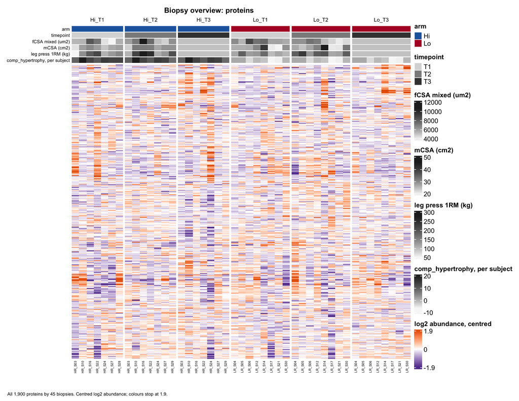

Figure 3: Every protein across biopsies, then across the nine contrasts.

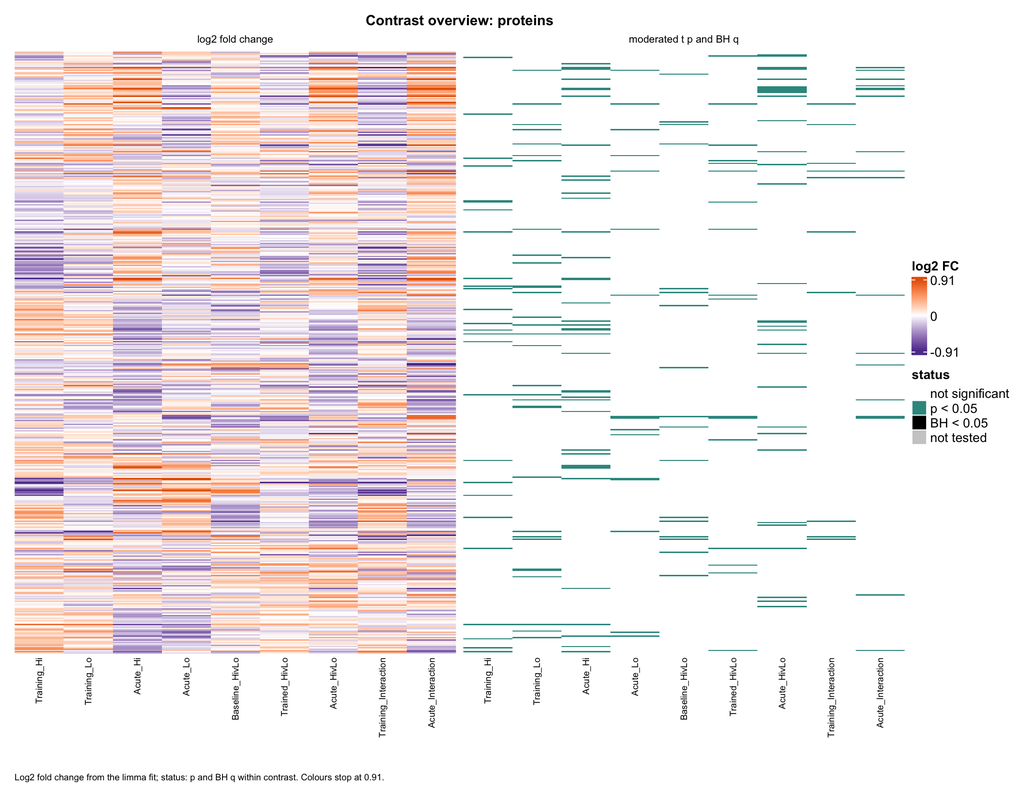

Figure 4: Every protein across biopsies, then across the nine contrasts.

```r
grey_ramp <- \(x) circlize::colorRamp2(range(x, na.rm = TRUE), c("#F7F7F7", "#252525"))
tracks <- list(
  "fCSA mixed (um2)" = columns$fcsa_mixed,
  "mCSA (cm2)" = columns$mcsa, "leg press 1RM (kg)" = columns$leg_press_1rm,
  "comp_hypertrophy, per subject" = columns$comp_hypertrophy
)
sample_annotation <- HeatmapAnnotation(
  df = data.frame(arm = columns$arm, timepoint = columns$timepoint, tracks, check.names = FALSE),
  col = c(
    list(arm = report_arm_colours, timepoint = c(T1 = "grey85", T2 = "grey55", T3 = "grey25")),
    map(tracks, grey_ramp)
  ),
  na_col = "grey80", annotation_name_gp = gpar(fontsize = 7), annotation_name_side = "left",
  simple_anno_size = unit(3, "mm")
)
effect_limit <- cap(contrast_results$effect)
overviews <- imap(row_groups, \(rows, group) {
  m <- sample_values[rows, columns$sample_id, drop = FALSE]
  m <- sweep(m, 1, rowMeans(m, na.rm = TRUE))
  limit <- cap(m)
  labelled_heat <- \(...) make_report_heatmap(..., labels = feature_label)
  biopsy_map <- labelled_heat(m, "biopsies", c(-limit, 0, limit), "log2 abundance, centred",
    row_names = TRUE, column_title = character(0), top_annotation = sample_annotation,
    column_split = columns$group, cluster_column_slices = FALSE,
    column_labels = columns$subject, column_names_gp = gpar(fontsize = 5)
  )
  contrast_grid <- \(value) {
    results_to_matrix(contrast_results, rows, contrast_names, "contrast", value)
  }
  contrast_maps <- labelled_heat(
    contrast_grid(\(d) d$effect), "log2 fold change", c(-effect_limit, 0, effect_limit), "log2 FC"
  ) +
    labelled_heat(contrast_grid(\(d) status_of(d$p, d$fdr)), "moderated t p and BH q",
      row_names = TRUE
    )
  list(
    heatmap_page(biopsy_map, sprintf("Biopsy overview: %s", group), paste(
      sprintf("All %s proteins by %d biopsies.", format(length(rows), big.mark = ","), ncol(m)),
      sprintf("Centred log2 abundance; colours stop at %.2g.", limit)
    ), legends = list()),
    heatmap_page(contrast_maps, sprintf("Contrast overview: %s", group), paste(
      "Log2 fold change from the limma fit; status: p and BH q within contrast.",
      sprintf("Colours stop at %.2g.", effect_limit)
    ))
  )
}) |>
  list_flatten()
walk(overviews, \(page) page$draw())
```

## Set trajectories

Each group’s p < 0.05 training sets (up and down), followed through T1, T2 and T3 in both groups: each person’s set mean on the blood-corrected matrix minus their own T1 value, then the mean and standard error across people. A person with no T1 biopsy drops out.

```r
corrected <- subset_for_design(readRDS(paths[["corrected"]]), d)
sample_meta <- as_tibble(meta)
stopifnot(identical(rownames(corrected$data), rownames(abundance)))
set_trajectory <- results |>
  filter(contrast %in% training, p < 0.05) |>
  mutate(set_from = contrast, set = if_else(logFC > 0, "nominal_up", "nominal_down")) |>
  summarise(members = list(uniprot_id), .by = c(set_from, set)) |>
  pmap(\(set_from, set, members) {
    tibble(
      sample_id = colnames(corrected$data),
      value = colMeans(corrected$data[members, , drop = FALSE])
    ) |>
      left_join(select(sample_meta, sample_id, subject, arm, timepoint), by = "sample_id") |>
      filter("T1" %in% timepoint, .by = subject) |>
      mutate(change = value - value[timepoint == "T1"], .by = subject) |>
      summarise(
        mean_change = mean(change), se = sd(change) / sqrt(n()), n_subjects = n(),
        .by = c(arm, timepoint)
      ) |>
      mutate(set_from = set_from, set = set, n_proteins = length(members), .before = 1)
  }) |>
  list_rbind()
head(set_trajectory, 6)
```

```
# A tibble: 6 × 8
  set_from    set       n_proteins arm   timepoint mean_change     se n_subjects
  <chr>       <chr>          <int> <fct> <fct>           <dbl>  <dbl>      <int>
1 Training_Hi nominal_…         46 Hi    T1             0      0               7
2 Training_Hi nominal_…         46 Lo    T1             0      0               8
3 Training_Hi nominal_…         46 Hi    T2            -0.614  0.178           6
4 Training_Hi nominal_…         46 Lo    T2            -0.134  0.0998          8
5 Training_Hi nominal_…         46 Hi    T3            -0.309  0.157           6
6 Training_Hi nominal_…         46 Lo    T3            -0.0431 0.107           8
```

## Whole-proteome structure

A PCA of the blood-corrected matrix (proteins scaled to unit variance), and PERMANOVA (vegan’s `adonis2()`, 9,999 permutations) on the Euclidean distances between runs. PERMANOVA asks how much of the distance between runs a factor explains (R²). Time is tested with permutations kept inside each person, so a person’s biopsies are compared with each other. Group is tested on one profile per person (the mean of their runs), or at one time point, so each person counts once.

```r
scaled <- scale(t(corrected$data))
pca <- prcomp(scaled)
pca_variance <- tibble(
  component = paste0("PC", 1:4),
  variance_explained = round(summary(pca)$importance[2, 1:4], 3)
)
pca_scores <- as_tibble(pca$x[, 1:2], rownames = "sample_id") |>
  left_join(select(sample_meta, sample_id, subject, arm, timepoint), by = "sample_id")
pca_variance
```

```
# A tibble: 4 × 2
  component variance_explained
  <chr>                  <dbl>
1 PC1                    0.139
2 PC2                    0.093
3 PC3                    0.08
4 PC4                    0.055
```

`permanova()` takes a row selection, the term to test and whether permutations stay within a person, and returns n, R², F and p. It is called once per window and group.

```r
permanova <- function(rows, term, within_subject) {
  x <- scaled[rows, , drop = FALSE]
  data <- sample_meta[rows, ]
  if (!within_subject && anyDuplicated(data$subject)) {
    x <- rowsum(x, data$subject) / as.vector(table(data$subject))
    data <- distinct(data, subject, arm)[match(rownames(x), unique(data$subject)), ]
  }
  control <- if (within_subject) {
    permute::how(blocks = factor(data$subject), nperm = 9999)
  } else {
    permute::how(nperm = 9999)
  }
  set.seed(1)
  fit <- vegan::adonis2(dist(x) ~ ., data = data[term], permutations = control)
  tibble(n_samples = nrow(x), r2 = fit$R2[1], f = fit$F[1], p = fit$`Pr(>F)`[1])
}
time_pairs <- list(all = c("T1", "T2", "T3"), training = c("T1", "T2"), acute = c("T2", "T3"))
global_tests <- bind_rows(
  imap(time_pairs, \(times, window) {
    map(c("both", arms), \(who) {
      rows <- sample_meta$timepoint %in% times & (who == "both" | sample_meta$arm == who)
      permanova(rows, "timepoint", within_subject = TRUE) |>
        mutate(term = "time", window = window, arms = who, .before = 1)
    })
  }) |>
    list_flatten() |>
    list_rbind(),
  map(c("subject mean", "T1", "T2", "T3"), \(when) {
    rows <- when == "subject mean" | sample_meta$timepoint == when
    permanova(rows, "arm", within_subject = FALSE) |>
      mutate(term = "arm", window = when, arms = "both", .before = 1)
  }) |>
    list_rbind()
)
```

The same test on the phenotype, the six size and strength traits at T1 and T2 scaled, with time within person, puts the proteome’s time effect beside the muscle’s own. Group is not tested here: HR/LR and the muscle clusters were split on these traits.

```r
trait_sets <- phenotype_tables(trait_table)
trait_rows <- filter(trait_sets$biopsy, if_all(all_of(trait_sets$traits), \(x) !is.na(x)))
set.seed(1)
trait_fit <- vegan::adonis2(
  dist(scale(trait_rows[trait_sets$traits])) ~ timepoint,
  data = trait_rows,
  permutations = permute::how(blocks = factor(trait_rows$subject), nperm = 9999)
)
global_tests <- global_tests |>
  mutate(data = "proteome", .before = 1) |>
  add_row(
    data = "phenotype", term = "time", window = "all", arms = "both",
    n_samples = nrow(trait_rows), r2 = trait_fit$R2[1], f = trait_fit$F[1],
    p = trait_fit$`Pr(>F)`[1]
  )
global_tests
```

```
# A tibble: 14 × 8
   data      term  window       arms  n_samples     r2     f      p
   <chr>     <chr> <chr>        <chr>     <int>  <dbl> <dbl>  <dbl>
 1 proteome  time  all          both         45 0.0633 1.42  0.0009
 2 proteome  time  all          Hi           21 0.111  1.12  0.117
 3 proteome  time  all          Lo           24 0.0828 0.948 0.0948
 4 proteome  time  training     both         30 0.0419 1.22  0.0515
 5 proteome  time  training     Hi           14 0.0761 0.989 0.328
 6 proteome  time  training     Lo           16 0.0558 0.828 0.312
 7 proteome  time  acute        both         30 0.0562 1.67  0.0005
 8 proteome  time  acute        Hi           14 0.101  1.35  0.0938
 9 proteome  time  acute        Lo           16 0.0711 1.07  0.125
10 proteome  arm   subject mean both         16 0.0663 0.994 0.424
11 proteome  arm   T1           both         15 0.0561 0.772 0.853
12 proteome  arm   T2           both         15 0.0595 0.822 0.845
13 proteome  arm   T3           both         15 0.0820 1.16  0.214
14 phenotype time  all          both         31 0.0355 1.07  0.0372
```

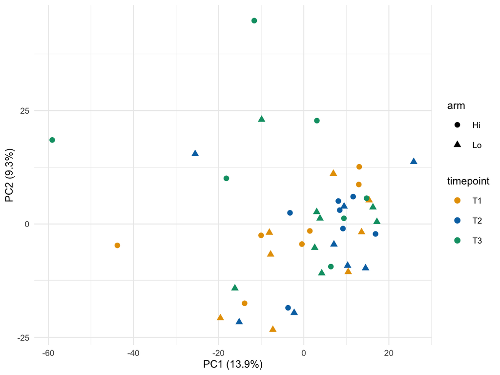

Figure 5: Runs on the blood-corrected matrix, proteins scaled.

```r
ggplot(pca_scores, aes(PC1, PC2, colour = timepoint, shape = arm)) +
  geom_point(size = 2) +
  scale_colour_manual(values = c(T1 = "#E69F00", T2 = "#0072B2", T3 = "#009E73")) +
  labs(
    x = sprintf("PC1 (%.1f%%)", 100 * pca_variance$variance_explained[1]),
    y = sprintf("PC2 (%.1f%%)", 100 * pca_variance$variance_explained[2])
  ) +
  theme_minimal(base_size = 9)
```

## Validation

```r
stopifnot(
  nrow(results) == nrow(proteins$E) * length(contrast_names),
  all(results$fdr >= results$p),
  all(results$logFC_lower <= results$logFC & results$logFC <= results$logFC_upper),
  !anyNA(results$p)
)
```

## Summary

```r
time_all <- global_tests |>
  filter(data == "proteome", term == "time", window == "all", arms == "both")
group_mean <- filter(global_tests, term == "arm", window == "subject mean")
```

1900 proteins were tested in each of the nine contrasts; 0 calls at BH < 0.05 across all nine (lowest BH 0.051). Proteins at p < 0.05 run from 41 to 189 per contrast; chance alone gives about 95. Time explains 6.3% of the distance between runs (PERMANOVA p = 0.0009); group, on one profile per person, 6.6% (p = 0.42). The median protein’s detectable training interaction is 0.95 log2 units.

## Save

`fit.rds` holds the fit, design and limpa’s matrix; the set and module contrasts read it.

```r
out <- here(stage, "c_data")
dir.create(out, recursive = TRUE, showWarnings = FALSE)
saveRDS(
  list(
    eBayes_fit = eb, design = dal$design, metadata = meta, data = proteins$E,
    annotation = dal$annotation, proteins = proteins
  ),
  file.path(out, "fit.rds"),
  compress = "xz"
)
write_workbook(
  list(
    protein_by_contrast = results |>
      mutate(n_obs = n_obs[uniprot_id]) |>
      select(
        contrast, uniprot_id, gene, n_obs, logFC, logFC_lower, logFC_upper, t, p, fdr, qvalue
      ) |>
      arrange(match(contrast, contrast_names), p),
    contrast_summary = contrast_summary,
    null_calibration = null_calibration,
    detectable_effect = tibble(
      contrast = "Training_Interaction", quantile = c(0.5, 0.9),
      log2_fc = round(quantile(detectable, c(0.5, 0.9), na.rm = TRUE, names = FALSE), 3)
    ),
    fry_concordance = fry_concordance,
    set_trajectory = set_trajectory,
    unadjusted = unadjusted,
    pca = pca_scores,
    pca_variance = pca_variance,
    permanova = global_tests
  ),
  c(
    paste(
      "One row per contrast and protein: logFC with its 95% CI, t, p, BH and Storey q, and the",
      "samples observed."
    ),
    "Tested, p < 0.05 and BH counts per contrast, with its role.",
    "propTrueNull, median |t| and share of p below 0.2 per contrast.",
    "log2 effect the primary contrast detects at 80% power, median and 90th percentile.",
    paste(
      "fry: one arm's responders tested in the other arm's contrast, and training sets on each",
      "arm's acute contrast; with mixed p, mean log2 FC in both contrasts and sign kept."
    ),
    "Training p < 0.05 sets: mean change from each subject's T1 (and SE) per arm and time point.",
    "logFC and p per protein and contrast before blood adjustment, for sensitivity.",
    "PC1 and PC2 per sample, from the complete blood-corrected matrix with proteins scaled.",
    "Share of variance on the first four components.",
    paste(
      "PERMANOVA (9,999 permutations): proteome time per window and arm, arm per time point;",
      "phenotype time."
    )
  ),
  file.path(out, "protein_contrasts.xlsx"),
  inputs, paths
)
```

```r
stack_inputs(here("03_Group_comparisons", "Proteome", "02_Protein_Contrasts"))
```